# MovieLens Project Solutions -Copy1

### Project - MovieLens Data Analysis

The GroupLens Research Project is a research group in the Department of Computer Science and Engineering at the University of Minnesota. The data is widely used for collaborative filtering and other filtering solutions. However, we will be using this data to act as a means to demonstrate our skill in using Python to “play” with data.

#### Domain

Internet and Entertainment

**Note that the project will need you to apply the concepts of groupby and merging extensively.**

```python
# I will import Seaborn and Matplotlib for visualiation
# I will import Pandas and Numpy for data analysis,manipulation and any numercal/scientifc computation that may arise
# I will also add cells
```

#### 1. Import the necessary packages - 2.5 marks

```python
import pandas as pd
import numpy as np
import matplotlib.pyplot as plt
import seaborn as sns
sns.set(color_codes=True)
%matplotlib inline
```

#### 2. Read the 3 datasets into dataframes - 2.5 marks

```python
Data = pd.read_csv('Data.csv')
Item = pd.read_csv('item.csv')
User = pd.read_csv('user.csv')
```

#### 3. Apply info, shape, describe, and find the number of missing values in the data - 5 marks

```python
Data.info()
```

```
<class 'pandas.core.frame.DataFrame'>
RangeIndex: 100000 entries, 0 to 99999
Data columns (total 4 columns):
 #   Column     Non-Null Count   Dtype
---  ------     --------------   -----
 0   user id    100000 non-null  int64
 1   movie id   100000 non-null  int64
 2   rating     100000 non-null  int64
 3   timestamp  100000 non-null  int64
dtypes: int64(4)
memory usage: 3.1 MB
```

```python
Item.info()
```

```
<class 'pandas.core.frame.DataFrame'>
RangeIndex: 1681 entries, 0 to 1680
Data columns (total 22 columns):
 #   Column        Non-Null Count  Dtype
---  ------        --------------  -----
 0   movie id      1681 non-null   int64
 1   movie title   1681 non-null   object
 2   release date  1681 non-null   object
 3   unknown       1681 non-null   int64
 4   Action        1681 non-null   int64
 5   Adventure     1681 non-null   int64
 6   Animation     1681 non-null   int64
 7   Childrens     1681 non-null   int64
 8   Comedy        1681 non-null   int64
 9   Crime         1681 non-null   int64
 10  Documentary   1681 non-null   int64
 11  Drama         1681 non-null   int64
 12  Fantasy       1681 non-null   int64
 13  Film-Noir     1681 non-null   int64
 14  Horror        1681 non-null   int64
 15  Musical       1681 non-null   int64
 16  Mystery       1681 non-null   int64
 17  Romance       1681 non-null   int64
 18  Sci-Fi        1681 non-null   int64
 19  Thriller      1681 non-null   int64
 20  War           1681 non-null   int64
 21  Western       1681 non-null   int64
dtypes: int64(20), object(2)
memory usage: 289.0+ KB
```

```python
User.info()
```

```
<class 'pandas.core.frame.DataFrame'>
RangeIndex: 943 entries, 0 to 942
Data columns (total 5 columns):
 #   Column      Non-Null Count  Dtype
---  ------      --------------  -----
 0   user id     943 non-null    int64
 1   age         943 non-null    int64
 2   gender      943 non-null    object
 3   occupation  943 non-null    object
 4   zip code    943 non-null    object
dtypes: int64(2), object(3)
memory usage: 37.0+ KB
```

```python
Data.shape
```

```
(100000, 4)
```

```python
Item.shape
```

```
(1681, 22)
```

```python
User.shape
```

```
(943, 5)
```

```python
Data.describe()
```

|  | user id | movie id | rating | timestamp |
| --- | --- | --- | --- | --- |
| count | 100000.00000 | 100000.000000 | 100000.000000 | 1.000000e+05 |
| mean | 462.48475 | 425.530130 | 3.529860 | 8.835289e+08 |
| std | 266.61442 | 330.798356 | 1.125674 | 5.343856e+06 |
| min | 1.00000 | 1.000000 | 1.000000 | 8.747247e+08 |
| 25% | 254.00000 | 175.000000 | 3.000000 | 8.794487e+08 |
| 50% | 447.00000 | 322.000000 | 4.000000 | 8.828269e+08 |
| 75% | 682.00000 | 631.000000 | 4.000000 | 8.882600e+08 |
| max | 943.00000 | 1682.000000 | 5.000000 | 8.932866e+08 |

```python
Item.describe()
```

|  | movie id | unknown | Action | Adventure | Animation | Childrens | Comedy | Crime | Documentary | Drama | Fantasy | Film-Noir | Horror | Musical | Mystery | Romance | Sci-Fi | Thriller | War | Western |
| --- | --- | --- | --- | --- | --- | --- | --- | --- | --- | --- | --- | --- | --- | --- | --- | --- | --- | --- | --- | --- |
| count | 1681.000000 | 1681.000000 | 1681.000000 | 1681.000000 | 1681.000000 | 1681.000000 | 1681.000000 | 1681.000000 | 1681.000000 | 1681.000000 | 1681.000000 | 1681.000000 | 1681.000000 | 1681.000000 | 1681.000000 | 1681.000000 | 1681.000000 | 1681.000000 | 1681.000000 | 1681.000000 |
| mean | 841.841761 | 0.000595 | 0.149316 | 0.080309 | 0.024985 | 0.072576 | 0.300416 | 0.064842 | 0.029744 | 0.431291 | 0.013087 | 0.014277 | 0.054729 | 0.033314 | 0.036288 | 0.146936 | 0.060083 | 0.149316 | 0.042237 | 0.016062 |
| std | 485.638077 | 0.024390 | 0.356506 | 0.271852 | 0.156126 | 0.259516 | 0.458576 | 0.246321 | 0.169931 | 0.495404 | 0.113683 | 0.118667 | 0.227519 | 0.179507 | 0.187061 | 0.354148 | 0.237712 | 0.356506 | 0.201189 | 0.125751 |
| min | 1.000000 | 0.000000 | 0.000000 | 0.000000 | 0.000000 | 0.000000 | 0.000000 | 0.000000 | 0.000000 | 0.000000 | 0.000000 | 0.000000 | 0.000000 | 0.000000 | 0.000000 | 0.000000 | 0.000000 | 0.000000 | 0.000000 | 0.000000 |
| 25% | 422.000000 | 0.000000 | 0.000000 | 0.000000 | 0.000000 | 0.000000 | 0.000000 | 0.000000 | 0.000000 | 0.000000 | 0.000000 | 0.000000 | 0.000000 | 0.000000 | 0.000000 | 0.000000 | 0.000000 | 0.000000 | 0.000000 | 0.000000 |
| 50% | 842.000000 | 0.000000 | 0.000000 | 0.000000 | 0.000000 | 0.000000 | 0.000000 | 0.000000 | 0.000000 | 0.000000 | 0.000000 | 0.000000 | 0.000000 | 0.000000 | 0.000000 | 0.000000 | 0.000000 | 0.000000 | 0.000000 | 0.000000 |
| 75% | 1262.000000 | 0.000000 | 0.000000 | 0.000000 | 0.000000 | 0.000000 | 1.000000 | 0.000000 | 0.000000 | 1.000000 | 0.000000 | 0.000000 | 0.000000 | 0.000000 | 0.000000 | 0.000000 | 0.000000 | 0.000000 | 0.000000 | 0.000000 |
| max | 1682.000000 | 1.000000 | 1.000000 | 1.000000 | 1.000000 | 1.000000 | 1.000000 | 1.000000 | 1.000000 | 1.000000 | 1.000000 | 1.000000 | 1.000000 | 1.000000 | 1.000000 | 1.000000 | 1.000000 | 1.000000 | 1.000000 | 1.000000 |

```python
User.describe()
```

|  | user id | age |
| --- | --- | --- |
| count | 943.000000 | 943.000000 |
| mean | 472.000000 | 34.051962 |
| std | 272.364951 | 12.192740 |
| min | 1.000000 | 7.000000 |
| 25% | 236.500000 | 25.000000 |
| 50% | 472.000000 | 31.000000 |
| 75% | 707.500000 | 43.000000 |
| max | 943.000000 | 73.000000 |

```python
Data.isnull().sum() # number of missing values per column in the Data.csv
```

```
user id      0
movie id     0
rating       0
timestamp    0
dtype: int64
```

```python
pd.DataFrame( Item.isnull().sum(), columns= ['Number of missing values']) # number of missing values per column in the item.csv
```

|  | Number of missing values |
| --- | --- |
| movie id | 0 |
| movie title | 0 |
| release date | 0 |
| unknown | 0 |
| Action | 0 |
| Adventure | 0 |
| Animation | 0 |
| Childrens | 0 |
| Comedy | 0 |
| Crime | 0 |
| Documentary | 0 |
| Drama | 0 |
| Fantasy | 0 |
| Film-Noir | 0 |
| Horror | 0 |
| Musical | 0 |
| Mystery | 0 |
| Romance | 0 |
| Sci-Fi | 0 |
| Thriller | 0 |
| War | 0 |
| Western | 0 |

```python
User.isnull().sum() # number of missing values per column in the user.csv
```

```
user id       0
age           0
gender        0
occupation    0
zip code      0
dtype: int64
```

```python
Data.isnull().sum().sum() # total number of missing values in Data.csv
```

```
0
```

```python
Item.isnull().sum().sum() # total number of missing values in item.csv
```

```
0
```

```python
User.isnull().sum().sum() # total number of missing values in user.csv
```

```
0
```

#### 4. Find the number of movies per genre using the item data - 5 marks

```python
# use sum on the default axis
Item.sum()
```

```
movie id                                                  1415136
movie title     Toy Story GoldenEye Four Rooms Get Shorty Copy...
release date    01-Jan-199501-Jan-199501-Jan-199501-Jan-199501...
unknown                                                         1
Action                                                        251
Adventure                                                     135
Animation                                                      42
Childrens                                                     122
Comedy                                                        505
Crime                                                         109
Documentary                                                    50
Drama                                                         725
Fantasy                                                        22
Film-Noir                                                      24
Horror                                                         92
Musical                                                        56
Mystery                                                        61
Romance                                                       247
Sci-Fi                                                        101
Thriller                                                      251
War                                                            71
Western                                                        27
dtype: object
```

```python
#hint: use sum on the axis
Item.groupby(['movie title','movie id']).sum()
```

| movie title | movie id | unknown | Action | Adventure | Animation | Childrens | Comedy | Crime | Documentary | Drama | Fantasy | Film-Noir | Horror | Musical | Mystery | Romance | Sci-Fi | Thriller | War | Western |
| --- | --- | --- | --- | --- | --- | --- | --- | --- | --- | --- | --- | --- | --- | --- | --- | --- | --- | --- | --- | --- |
| 'Til There Was You | 1300 | 0 | 0 | 0 | 0 | 0 | 0 | 0 | 0 | 1 | 0 | 0 | 0 | 0 | 0 | 1 | 0 | 0 | 0 | 0 |
| 1-900 | 1353 | 0 | 0 | 0 | 0 | 0 | 0 | 0 | 0 | 0 | 0 | 0 | 0 | 0 | 0 | 1 | 0 | 0 | 0 | 0 |
| 101 Dalmatians | 225 | 0 | 0 | 0 | 0 | 1 | 1 | 0 | 0 | 0 | 0 | 0 | 0 | 0 | 0 | 0 | 0 | 0 | 0 | 0 |
| 12 Angry Men | 178 | 0 | 0 | 0 | 0 | 0 | 0 | 0 | 0 | 1 | 0 | 0 | 0 | 0 | 0 | 0 | 0 | 0 | 0 | 0 |
| 187 | 330 | 0 | 0 | 0 | 0 | 0 | 0 | 0 | 0 | 1 | 0 | 0 | 0 | 0 | 0 | 0 | 0 | 0 | 0 | 0 |
| ... | ... | ... | ... | ... | ... | ... | ... | ... | ... | ... | ... | ... | ... | ... | ... | ... | ... | ... | ... | ... |
| Young Guns | 232 | 0 | 1 | 0 | 0 | 0 | 1 | 0 | 0 | 0 | 0 | 0 | 0 | 0 | 0 | 0 | 0 | 0 | 0 | 1 |
| Young Guns II | 1188 | 0 | 1 | 0 | 0 | 0 | 1 | 0 | 0 | 0 | 0 | 0 | 0 | 0 | 0 | 0 | 0 | 0 | 0 | 1 |
| Young Poisoner's Handbook, The | 547 | 0 | 0 | 0 | 0 | 0 | 0 | 1 | 0 | 0 | 0 | 0 | 0 | 0 | 0 | 0 | 0 | 0 | 0 | 0 |
| Zeus and Roxanne | 1164 | 0 | 0 | 0 | 0 | 1 | 0 | 0 | 0 | 0 | 0 | 0 | 0 | 0 | 0 | 0 | 0 | 0 | 0 | 0 |
| Á köldum klaka (Cold Fever) | 1633 | 0 | 0 | 0 | 0 | 0 | 1 | 0 | 0 | 1 | 0 | 0 | 0 | 0 | 0 | 0 | 0 | 0 | 0 | 0 |

1680 rows × 19 columns

#### 6. Drop the movie where the genre is unknown - 2.5 marks

```python
NItem = Item[Item['unknown']>=1]   # This is just to see which movie has a genre that is unknown
```

```python
Item.drop(Item[Item['unknown']>=1].index, inplace = True) # Drop the movie that has the unknown genre
```

### 7. Univariate plots of columns: 'rating', 'Age', 'release year', 'Gender' and 'Occupation' - 10 marks

```python
# HINT: use distplot for age and countplot for gender,ratings,occupation.
# HINT: Please refer to the below snippet to understand how to get to release year from release date. You can use str.split()
# as depicted below
# Hint : Use displot without kde for release year or line plot showing year wise count.
```

```python
a = 'My*cat*is*brown'
print(a.split('*')[3])

#similarly, the release year needs to be taken out from release date

#also you can simply slice existing string to get the desired data, if we want to take out the colour of the cat

print(a[10:])
print(a[-5:])
```

```
brown
brown
brown
```

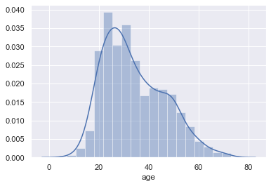

```python
sns.distplot(User['age'])
```

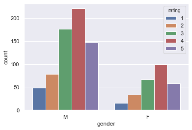

```python
sns.countplot(User['gender'],hue=Data['rating'])
```

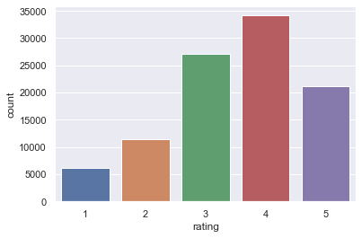

```python
sns.countplot(Data['rating'])
```

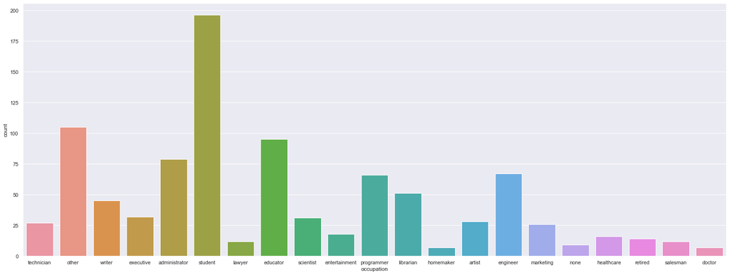

```python
plt.figure(figsize=(27,10))
sns.countplot(User['occupation'])
```

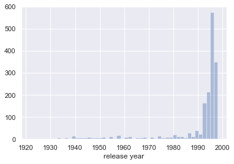

```python
Item['release year'] = Item['release date'].str.split("-").str[2]
Item['release year']
sns.distplot(Item['release year'], kde=False)
```

### 8. Visualize how popularity of genres has changed over the years - 10 marks

Note that you need to use the number of releases in a year as a parameter of popularity of a genre

Hint

1: you need to reach to a data frame where the release year is the index and the genre is the column names (one cell shows the number of release in a year in one genre) or vice versa. Once that is achieved, you can either use univariate plots or can use the heatmap to visualise all the changes over the years in one go.

Hint 2: Use groupby on the relevant column and use sum() on the same to find out the nuumber of releases in a year/genre.

```python
#Your answer here
New_Item = Item.drop(['movie id'], axis = 1)
Item2 = New_Item.groupby(['release year']).sum()
Item2
```

| release year | unknown | Action | Adventure | Animation | Childrens | Comedy | Crime | Documentary | Drama | Fantasy | Film-Noir | Horror | Musical | Mystery | Romance | Sci-Fi | Thriller | War | Western |
| --- | --- | --- | --- | --- | --- | --- | --- | --- | --- | --- | --- | --- | --- | --- | --- | --- | --- | --- | --- |
| 1922 | 0 | 0 | 0 | 0 | 0 | 0 | 0 | 0 | 0 | 0 | 0 | 1 | 0 | 0 | 0 | 0 | 0 | 0 | 0 |
| 1926 | 0 | 0 | 0 | 0 | 0 | 0 | 0 | 0 | 1 | 0 | 0 | 0 | 0 | 0 | 0 | 0 | 0 | 0 | 0 |
| 1930 | 0 | 0 | 0 | 0 | 0 | 0 | 0 | 0 | 1 | 0 | 0 | 0 | 0 | 0 | 0 | 0 | 0 | 0 | 0 |
| 1931 | 0 | 0 | 0 | 0 | 0 | 0 | 1 | 0 | 0 | 0 | 1 | 0 | 0 | 0 | 0 | 0 | 1 | 0 | 0 |
| 1932 | 0 | 0 | 0 | 0 | 0 | 0 | 0 | 0 | 0 | 0 | 0 | 0 | 0 | 0 | 1 | 0 | 0 | 1 | 0 |
| ... | ... | ... | ... | ... | ... | ... | ... | ... | ... | ... | ... | ... | ... | ... | ... | ... | ... | ... | ... |
| 1994 | 0 | 30 | 13 | 4 | 15 | 82 | 8 | 9 | 97 | 3 | 0 | 8 | 2 | 2 | 35 | 7 | 25 | 7 | 6 |
| 1995 | 0 | 40 | 22 | 6 | 21 | 63 | 11 | 5 | 89 | 3 | 1 | 14 | 3 | 5 | 37 | 15 | 39 | 5 | 2 |
| 1996 | 0 | 44 | 24 | 9 | 21 | 108 | 21 | 18 | 170 | 6 | 1 | 11 | 9 | 6 | 38 | 15 | 47 | 9 | 2 |
| 1997 | 0 | 46 | 20 | 3 | 22 | 87 | 30 | 6 | 113 | 4 | 2 | 8 | 5 | 18 | 51 | 13 | 54 | 14 | 0 |
| 1998 | 0 | 12 | 3 | 0 | 1 | 13 | 7 | 3 | 33 | 1 | 2 | 4 | 1 | 3 | 11 | 5 | 18 | 0 | 0 |

71 rows × 19 columns

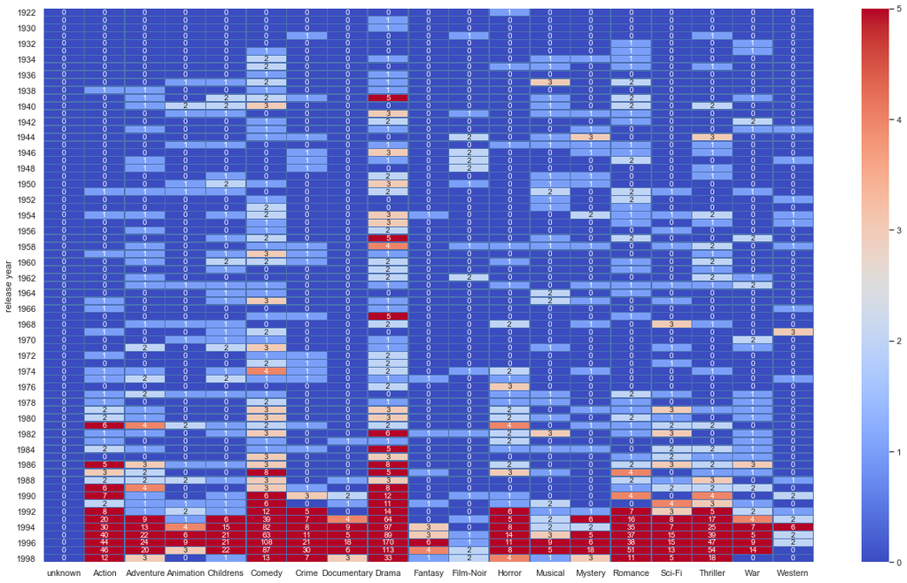

```python
plt.figure(figsize = (22,13))
sns.heatmap(Item2, annot = True, fmt = '.0f', linewidths=.5, cmap = 'coolwarm', vmin = 0, vmax = 5, linecolor = "bb")  # heatmap
```